# ETC5523: Communicating with Data

Tutorial 5

Author

Michael Lydeamore

Published

May 1, 2001

## 🎯 Objectives

- create new functions and generic methods
- understand and follow guidelines for best way to communicate with tables
- construct regression, descriptive, and interactive tables with R Markdown
- deconstruct and manipulate “novel” model objects
- modify the look of *HTML tables* produced by R Markdown or Quarto

**Preparation**

Install the R-packages

```r
install.packages(c("broom", "DT", "kableExtra", "palmerpenguins", "modelsummary", "gtsummary"))
```

## 🛠️ Exercise 5A

**Create new generic methods**

The `range` function in R returns a vector containing the minimum and maximum. However, the statistical definition of a range of a set of data is the *difference* between the largest and smallest values.

- Create a new function called `myrange` that computes the difference between the largest and smallest values for vectors of classes: `integer`, `numeric`, `Date` and `POSIXct` (or more generally `POSIXt`).
- In addition if the vector is a character with only one letter for each element, compute the position difference in the English alphabet (e.g. a vector with “A” and “B” should return 1). Cases can be ignored (e.g. a vector with “a” and “B” should return 1). Hint: `?match`, `?tolower` and `?letters`.
- Design your functions as S3 generic methods.
- Test your function for the following data:

```r
x1 <- c(2L, 1L, 0L, 3L, 9L, 2L, 3L, 1L, 1L, 5L)
x2 <- c(6.1, -0.6, 5.2, 7.8, NA, 0.7, 4.3, 5.6, 5.6, 4, 0.4)
x3 <- as.Date(c("2021-08-01", "2021-08-04", NA, "2021-08-02", "2021-07-08", "2021-07-09",  "2021-07-30", "2021-07-12", "2021-07-26", "2021-07-22", "2021-08-08"))
x4 <- as.POSIXct(c("2021-08-08 19:26:32", "2021-08-08 19:26:48", "2021-08-03 01:27:02",
"2021-08-08 19:26:31", "2021-08-08 19:26:29", "2021-08-08 19:26:57",
"2021-08-08 19:26:54", "2021-08-08 19:26:59", "2021-08-08 19:26:27",
"2021-08-08 19:26:38"), tz = "UTC")
x5 <- c("N", "X", "E", "l", "Y", "u", "M", "S", "D", "A")
```

**Solution**

```r
library(palmerpenguins)
library(tidyverse)
library(broom)
library(MASS)

myrange <- function(x, ...) UseMethod("myrange")
myrange.default <- function(x, na.rm = TRUE) {
  max(x, na.rm = na.rm) - min(x, na.rm = na.rm)
}
myrange.character <- function(x, na.rm = TRUE) {
  if(any(nchar(x) != 1)) {
    stop("One of the character is not of length 1")
  }
  xmin <- match(tolower(min(x)), letters)
  xmax <- match(tolower(max(x)), letters)
  xmax - xmin
}

x1 <- c(2L, 1L, 0L, 3L, 9L, 2L, 3L, 1L, 1L, 5L)
x2 <- c(6.1, -0.6, 5.2, 7.8, NA, 0.7, 4.3, 5.6, 5.6, 4, 0.4)
x3 <- as.Date(c("2021-08-01", "2021-08-04", NA, "2021-08-02", "2021-07-08", "2021-07-09",  "2021-07-30", "2021-07-12", "2021-07-26", "2021-07-22", "2021-08-08"))
x4 <- as.POSIXct(c("2021-08-08 19:26:32", "2021-08-08 19:26:48", "2021-08-03 01:27:02",
"2021-08-08 19:26:31", "2021-08-08 19:26:29", "2021-08-08 19:26:57",
"2021-08-08 19:26:54", "2021-08-08 19:26:59", "2021-08-08 19:26:27",
"2021-08-08 19:26:38"), tz = "UTC")
x5 <- c("N", "X", "E", "l", "Y", "u", "M", "S", "D", "A")

myrange(x1)
```

```
[1] 9
```

```r
myrange(x2)
```

```
[1] 8.4
```

```r
myrange(x3)
```

```
Time difference of 31 days
```

```r
myrange(x4)
```

```
Time difference of 5.749965 days
```

```r
myrange(x5)
```

```
[1] 24
```

## 👥 Exercise 5B

**Working with robust linear models**

Consider the artificial data in the object `df`. There are two obvious outliers. Which observations are the outliers?

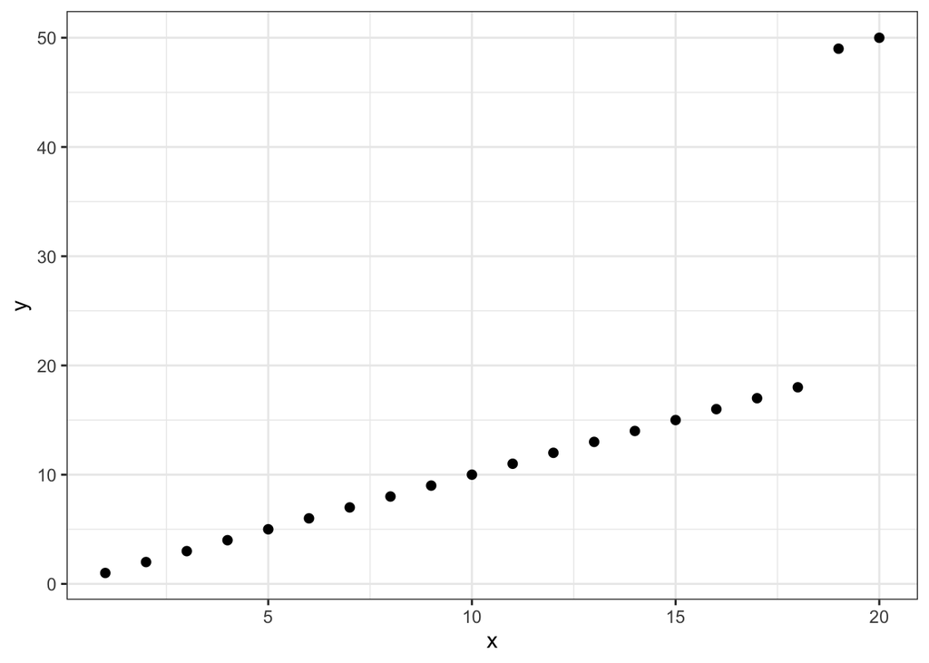

```r
library(tidyverse)
library(broom)
library(palmerpenguins)
library(MASS) # needed for rlm
df <- tibble(x = 1:20, y = c(1:18, 49:50))
ggplot(df, aes(x, y)) +
  geom_point(size = 2) + theme_bw(base_size = 12)
```

A simple linear model where parameters are estimated using least squares estimate are not robust to outliers. Below we fit two models:

1. a linear model with least square estimates contained in `fit_lm` and
2. a robust linear model contained in `fit_rlm`.

To explain briefly, a robust linear model down-weights the contribution of the observations that are outlying observations to estimate parameters.

```r
fit_lm <- lm(y ~ x, data = df)
fit_rlm <- rlm(y ~ x, data = df)
```

What is the class of `fit_rlm`? Study the object structure of both `fit_lm` and `fit_rlm`. How are the structures different between `fit_lm` and `fit_rlm`?

Below the `augment` method from the `broom` package extracts some model-related values but it does not return the weights from the iterated re-weighted least squares. Modify the `augment` method for the appropriate class so that the code below gets the desired output.

```r
# modify augment method to the desired output
dfa <- augment(fit_rlm)
```

**Open here for the desired output for `dfa`**

```
dfa
# A tibble: 20 x 7
       y     x .fitted     .resid      .hat .sigma         w
   <int> <int>   <dbl>      <dbl>     <dbl>  <dbl>     <dbl>
 1     1     1   0.999  0.000546  0.206      10.3  1
 2     2     2   2.00   0.000452  0.172      10.3  1
 3     3     3   3.00   0.000358  0.143      10.3  1
 4     4     4   4.00   0.000263  0.118      10.3  1
 5     5     5   5.00   0.000169  0.0974     10.3  1
 6     6     6   6.00   0.0000749 0.0808     10.3  1
 7     7     7   7.00  -0.0000193 0.0685     10.3  1
 8     8     8   8.00  -0.000114  0.0603     10.3  1
 9     9     9   9.00  -0.000208  0.0564     10.3  1
10    10    10  10.0   -0.000302  0.0566     10.3  1
11    11    11  11.0   -0.000396  0.0611     10.3  1
12    12    12  12.0   -0.000490  0.0698     10.3  1
13    13    13  13.0   -0.000585  0.0827     10.3  1
14    14    14  14.0   -0.000679  0.0998     10.3  1
15    15    15  15.0   -0.000773  0.121      10.3  1
16    16    16  16.0   -0.000867  0.147      10.3  1
17    17    17  17.0   -0.000961  0.172      10.3  0.977
18    18    18  18.0   -0.00106   0.187      10.3  0.890
19    49    19  19.0   30.0       0.0000184   7.28 0.0000742
20    50    20  20.0   30.0       0.0000216   7.28 0.0000742
```

Once the above is done, you can use the code below to get the plot seen at the end of this question. What do you think the `w` is doing?

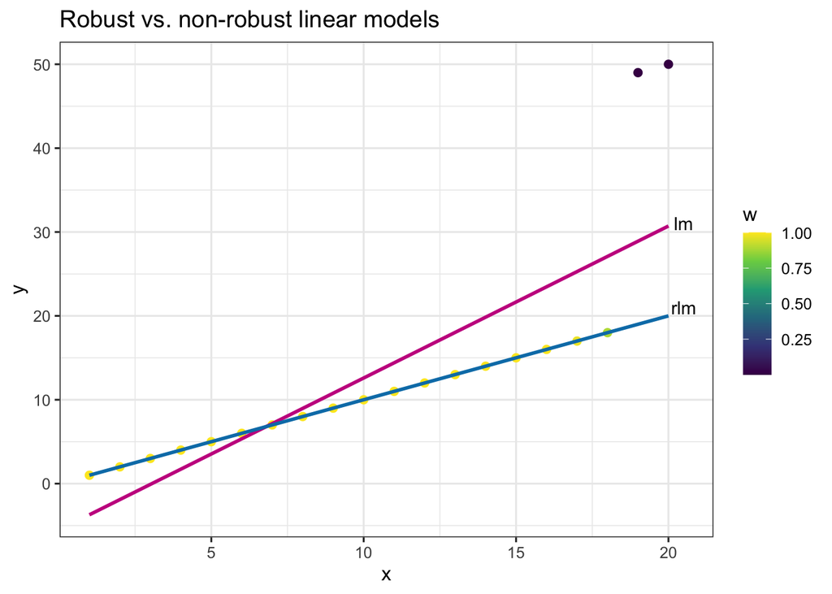

```r
ggplot(dfa, aes(x, y, color = w)) +
  geom_point(size = 2) +
  geom_smooth(method = "lm", se = FALSE, color = "#C8008F") +
  geom_smooth(method = "rlm", se = FALSE, color = "#027EB6") +
  annotate("text", x = 20.5, y = c(21, 31),
           label = c("rlm", "lm")) +
  theme_bw(base_size = 12) +
  labs(title = "Robust vs. non-robust linear models") +
  scale_color_continuous(type = "viridis")
```

**Solution**

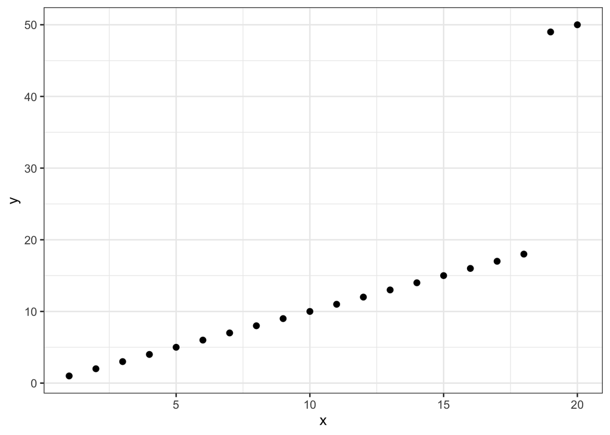

```r
df <- tibble(x = 1:20, y = c(1:18, 49:50))

ggplot(df, aes(x, y)) +
  geom_point(size = 2) + theme_bw(base_size = 12)
```

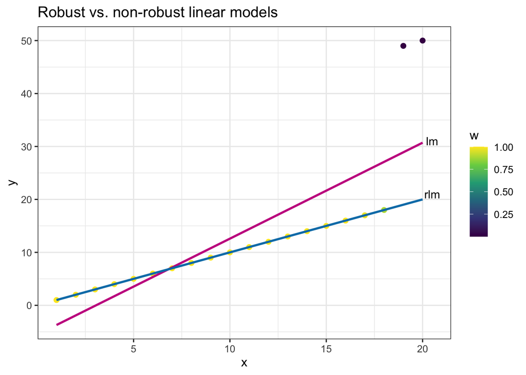

```r
fit_lm <- lm(y ~ x, data = df)
fit_rlm <- rlm(y ~ x, data = df)


augment.rlm <- function(fit, ...) {
   broom:::augment.rlm(fit) %>%
    mutate(w = fit$w)
}
dfa <- augment(fit_rlm)

ggplot(dfa, aes(x, y, color = w)) +
  geom_point(size = 2) +
  geom_smooth(method = "lm", se = FALSE, color = "#C8008F") +
  geom_smooth(method = "rlm", se = FALSE, color = "#027EB6") +
  annotate("text", x = 20.5, y = c(21, 31),
           label = c("rlm", "lm")) +
  theme_bw(base_size = 12) +
  labs(title = "Robust vs. non-robust linear models") +
  scale_color_continuous(type = "viridis")
```

## 👥 Exercise 5C

**Reporting regression tables**

Create regression tables, respecting the standard guidelines of presentation for tables, with models `lm1` and `rlm1` below using `modelsummary`, `gtsummary` or otherwise.

```r
library(palmerpenguins)
lm1 <- lm(bill_length_mm ~ species + bill_depth_mm + flipper_length_mm + body_mass_g + sex, data = penguins)
rlm1 <- rlm(bill_length_mm ~ . , data = penguins)
```

**Solution**

```r
lm1 <- lm(bill_length_mm ~ species + bill_depth_mm + flipper_length_mm + body_mass_g + sex, data = penguins)
rlm1 <- rlm(bill_length_mm ~ . , data = penguins)
modelsummary::modelsummary(models = list(lm1, rlm1))
```

|  | (1) | (2) |
| --- | --- | --- |
| (Intercept) | 15.017 | −563.241 |
|  | (4.374) | (297.257) |
| speciesChinstrap | 9.566 | 9.911 |
|  | (0.350) | (0.390) |
| speciesGentoo | 6.404 | 6.687 |
|  | (1.030) | (1.028) |
| bill_depth_mm | 0.313 | 0.320 |
|  | (0.154) | (0.142) |
| flipper_length_mm | 0.069 | 0.062 |
|  | (0.023) | (0.023) |
| body_mass_g | 0.001 | 0.001 |
|  | (0.000) | (0.000) |
| sexmale | 2.030 | 2.331 |
|  | (0.389) | (0.356) |
| islandDream |  | −0.538 |
|  |  | (0.412) |
| islandTorgersen |  | 0.034 |
|  |  | (0.430) |
| year |  | 0.289 |
|  |  | (0.149) |
| Num.Obs. | 333 | 333 |
| R2 | 0.839 |  |
| R2 Adj. | 0.836 |  |
| AIC | 1484.3 | 1488.7 |
| BIC | 1514.7 | 1530.6 |
| Log.Lik. | −734.127 | −733.370 |
| RMSE | 2.19 | 2.19 |

## 🛠️ Exercise 5D

**Interactive data tables**

Produce the same table that you find below using `DT` using the `penguins` data in the `palmerpenguins` package.

[interactive chart not shown]

**Solution**

**Below is the content of `tutorial-05-supp.Rmd`** (scroll to see all) or download the file here.

````markdown
---
title: 'ETC5523: Communicating with Data'
subtitle: "Tutorial 5 Supp"
author: "Michael Lydeamore"
date: "Week 5"
output: html_document
---

```{css, echo = FALSE}
thead {
  background-color: #006DAE;
  color: white;
}
```

```{r setup, include = FALSE}
library(palmerpenguins)
library(tidyverse)
library(DT)
knitr::opts_chunk$set(
  echo = FALSE,
  message = FALSE,
  warning = FALSE
)
```

# Exploring bill length (mm) of palmer penguins

```{r}
penguins %>%
  group_by(species) %>%
  summarise(
    fivenum = list(setNames(as.vector(summary(na.omit(bill_length_mm))),
                   c("Min", "Q1", "Median", "Mean", "Q3", "Max")))) %>%
  unnest_wider(fivenum) %>%
  datatable(escape = FALSE,
            options = list(paging = FALSE,
                           dom = "t")) %>%
  formatRound(columns = c("Min", "Q1", "Mean", "Median", "Q3", "Max"), digits = 2)
```
````